# Discrimination in the Incarceration System

Anahi Villanueva

2022-11-21

## Abstract

In this assignment I will be creating graphs and maps with the intention to show how the incarceration rates over the years between 1970 and 2018 have increased. With the data I will also be showing how this increment has been affecting mainly minority communities in the United States. This assignment has comparisons between races and gender and in summaries I have written about why I selected certain specific data such as Latinx (I am Mexican).

## Introduction

Incarceration separates many families. It makes many kids grow up in a household where they don’t get to see one of their parents often. Also, many get to grow up with a wrong idea of who their family member was due to all the wrong information that gets shared. The Vera Institute does research on the incarceration trends and releases this information to the public. The data that they collect, they share it with the world as they tend to inform people about racial disparities that occur and the impact that it has on many people. With this data there are direct stakeholders and indirect stakeholders. Direct stakeholders are those that directly interact with the system such as lawyers, people interested in knowing about incarceration information, and social justice movements. Indirect stakeholders are those that are affected by this system without using it themselves. Some indirect stakeholders may be the prisons from where this data was collected from and citizens. This data has really important information that should not be disregarded and that can be used to expose patterns of inequality.

## Data Summary

I decided to focus my variable on gender and race. The first function that I did was to find the county that has the highest number of black people between the ages 15 to 64 in jail. This data goes all the way to the year 2018 so I filter my data to find the maximum but for this year. The county name that I received was New York County. This is important as it helps understand the patterns of inequality that exist in the prison system.

The other function that I did was to find what county has the least latinx people ages 15 to 64 in 2018, as it’s the closest year to 2022, in jail. I wanted to know this because I am Latina and also because the main goal of this project is to find data that will help find patterns of inequality and I feel like this can help. I got really interested especially in knowing this and I found out that the county was Wade Hampton Census Area.

Another pattern of inequality that I think is important and that’s why I decided to do it is gender. I feel like there’s a pattern of inequality on the amount of males that go to jail and the amount of females that go to jail. My understanding is that there are more males that go jail and the average was higher for males than for females. For males it was 143.6054915 while the average for females was 18.2104312. This helps understand those inequalities that occur in the prison systems.

## Growth of the U.S. Prison Population

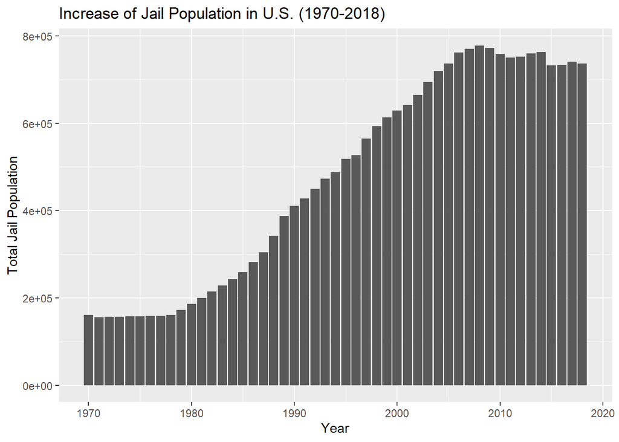

**Figure 1:** The increasement of people in jail in the U.S. over the years between 1970 and 2018.

### **Summary Paragraph:**

In this chart the key pattern that is revealed is that over the years the amount of people in jail grew in the United States. The graph shows how in the 1970s to around the 1980s the jail population stayed about the same. In the 1980s it started to increase little by little until like 2008 where it was at its highest and then it decreased a little yet it’s still really high.

## Growth of Prison Population by State

[figure not shown]

## Variable Comparison Revealing Patterns of Inequality

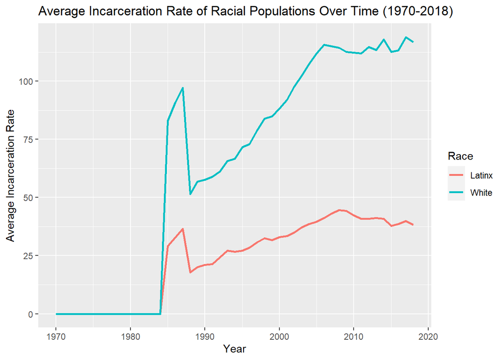

**Figure 3:** This chart shows the average incarceration rates between Whites and Latinx over the years. The White population incarceration rate has increased over the years more than the one for the Latinx population.

## Variable Distributed Geographically Revealing Patterns of Inequality

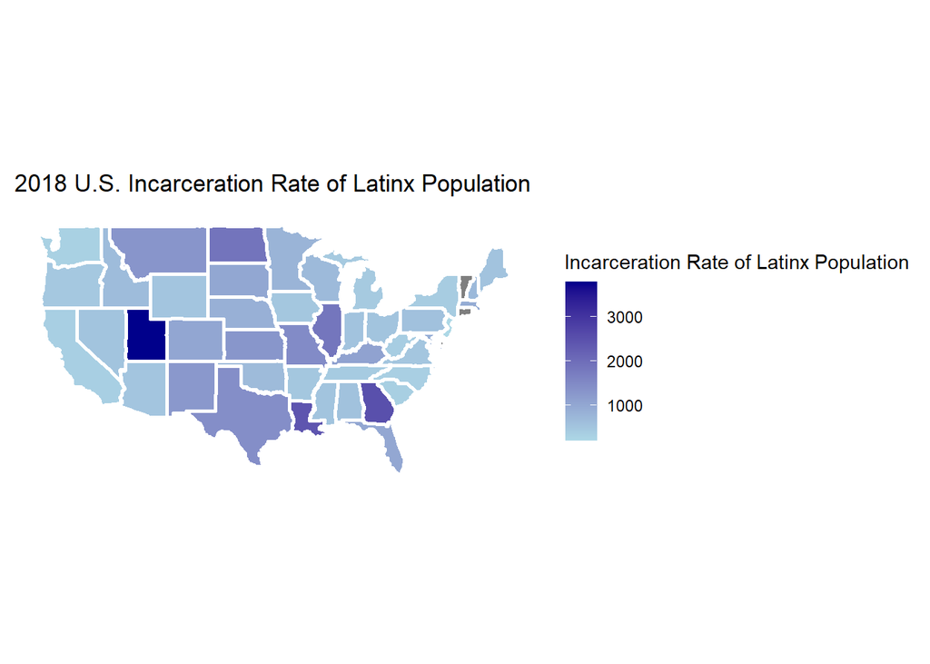

**Figure 4:** This map shows how the Latinx jail population is distributed geographically in the U.S.

### **Summary Paragraph:**

*What state has the highest jail population rate for Latinx?* With the Latinx population the state with the highest jail population rate is Utah. This map was created using the data from the incarceration_trends and it shows the incarceration rate from lowest (being the lightest colors) to highest (being the darkest colors).